# Characteristics Full-Length Feature Films

- Introduction
- Data Wrangling
- Exploratory Data Analysis
- Conclusions
- References

## Introduction

> This dataset contains information of over 10,000 movies from 1960 to 2015 collected by The Movie Database (TMDb). We will identify certain features that makes up a high-grossing movie and the timing of its releases. Finally, we'll look at popular genres of feature films over the years.

```python
# The libraries we'll be using are NumPy for multidimensional arrays, pandas for data manipulation and analysis,
# and matplotlib and seaborn for visualization.

import numpy as np
import pandas as pd
import matplotlib.pyplot as plt
import seaborn as sns
sns.set()
%matplotlib inline
```

## Data Wrangling

### General Properties

```python
# load the dataset
movies = pd.read_csv('tmdb-movies.csv')
```

```python
# size of the dataset
movies.shape
```

```
(10866, 21)
```

```python
# summary of the dataset
movies.info()
```

```
<class 'pandas.core.frame.DataFrame'>
RangeIndex: 10866 entries, 0 to 10865
Data columns (total 21 columns):
 #   Column                Non-Null Count  Dtype
---  ------                --------------  -----
 0   id                    10866 non-null  int64
 1   imdb_id               10856 non-null  object
 2   popularity            10866 non-null  float64
 3   budget                10866 non-null  int64
 4   revenue               10866 non-null  int64
 5   original_title        10866 non-null  object
 6   cast                  10790 non-null  object
 7   homepage              2936 non-null   object
 8   director              10822 non-null  object
 9   tagline               8042 non-null   object
 10  keywords              9373 non-null   object
 11  overview              10862 non-null  object
 12  runtime               10866 non-null  int64
 13  genres                10843 non-null  object
 14  production_companies  9836 non-null   object
 15  release_date          10866 non-null  object
 16  vote_count            10866 non-null  int64
 17  vote_average          10866 non-null  float64
 18  release_year          10866 non-null  int64
 19  budget_adj            10866 non-null  float64
 20  revenue_adj           10866 non-null  float64
dtypes: float64(4), int64(6), object(11)
memory usage: 1.7+ MB
```

```python
# descriptive statistic summary of the dataset
movies.describe()
```

|  | id | popularity | budget | revenue | runtime | vote_count | vote_average | release_year | budget_adj | revenue_adj |
| --- | --- | --- | --- | --- | --- | --- | --- | --- | --- | --- |
| count | 10866.000000 | 10866.000000 | 1.086600e+04 | 1.086600e+04 | 10866.000000 | 10866.000000 | 10866.000000 | 10866.000000 | 1.086600e+04 | 1.086600e+04 |
| mean | 66064.177434 | 0.646441 | 1.459050e+07 | 3.982332e+07 | 102.070863 | 217.389748 | 5.974922 | 2001.322658 | 1.751584e+07 | 5.136436e+07 |
| std | 92130.136561 | 1.000185 | 3.066263e+07 | 1.170035e+08 | 31.381405 | 575.619058 | 0.935142 | 12.812941 | 3.408355e+07 | 1.446325e+08 |
| min | 5.000000 | 0.000065 | 0.000000e+00 | 0.000000e+00 | 0.000000 | 10.000000 | 1.500000 | 1960.000000 | 0.000000e+00 | 0.000000e+00 |
| 25% | 10596.250000 | 0.207583 | 0.000000e+00 | 0.000000e+00 | 90.000000 | 17.000000 | 5.400000 | 1995.000000 | 0.000000e+00 | 0.000000e+00 |
| 50% | 20669.000000 | 0.383856 | 0.000000e+00 | 0.000000e+00 | 99.000000 | 38.000000 | 6.000000 | 2006.000000 | 0.000000e+00 | 0.000000e+00 |
| 75% | 75610.000000 | 0.713817 | 1.500000e+07 | 2.400000e+07 | 111.000000 | 145.750000 | 6.600000 | 2011.000000 | 2.085325e+07 | 3.369710e+07 |
| max | 417859.000000 | 32.985763 | 3.800000e+08 | 2.781506e+09 | 900.000000 | 9767.000000 | 9.200000 | 2015.000000 | 3.683713e+08 | 2.827124e+09 |

```python
# number of rows with 0 revenue
len(movies[movies.revenue == 0])
```

```
6016
```

```python
# check for duplicates
movies[movies.duplicated()]
```

|  | id | imdb_id | popularity | budget | revenue | original_title | cast | homepage | director | tagline | ... | overview | runtime | genres | production_companies | release_date | vote_count | vote_average | release_year | budget_adj | revenue_adj |
| --- | --- | --- | --- | --- | --- | --- | --- | --- | --- | --- | --- | --- | --- | --- | --- | --- | --- | --- | --- | --- | --- |
| 2090 | 42194 | tt0411951 | 0.59643 | 30000000 | 967000 | TEKKEN | Jon Foo\|Kelly Overton\|Cary-Hiroyuki Tagawa\|Ian... | NaN | Dwight H. Little | Survival is no game | ... | In the year of 2039, after World Wars destroy ... | 92 | Crime\|Drama\|Action\|Thriller\|Science Fiction | Namco\|Light Song Films | 3/20/2010 | 110 | 5.0 | 2010 | 30000000.0 | 967000.0 |

1 rows × 21 columns

### Initial Findings

There are 10,866 rows and 21 columns in this dataset. We will only keep columns that are relevant in this report and drop the remaining. Features that will be used in this analysis are defined below:

**budget**: the total budget of the movie in U.S. Dollars\ **revenue**: the total revenue of the movie in U.S. Dollars\ **original_title**: the official title of the movie\ **genres**: a list of genres associated with the movie\ **release_date**: the month, date, year the movie was released\ **vote_count**: the number of user votes\ **vote_average**: the average rating of the movie\ **release_year**: the year the movie was released\ **budget_adj**: the total budget of the movie in U.S. Dollars adjusted to account inflation\ **revenue_adj**: the total revenue of the movie in U.S. Dollars adjusted to account inflation

*popularity*\ TMDb's documentation on popularity is defined as a measure by user interaction on a certain day. This feature is excluded as it may be biased on recently released movies and may not result in accurate analysis. (*https://developers.themoviedb.org/3/getting-started/popularity*)

*revenue & revenue_adj*\ The revenue and revenue_adj columns doesn't appear to have any null values. However, it shows that 6,016 rows have zero revenue. Because we're analyzing the characteristics and features of high-grossing movies, we need data with reported revenue figures.

*new column*\ This analysis will include movie release dates at the month level. The release_date column will not used directly in this report but will be helpful to extract the release month. Additional column for the release month will be added to the dataset.

*duplicate*\ One duplicate row will be dropped.

### Data Cleaning

#### Drop all columns not relevant in the analysis.

```python
# create a list of columns that will be dropped
columns = ['id', 'imdb_id', 'popularity','cast', 'homepage', 'director', 'tagline', 'keywords', 'overview',
       'runtime', 'production_companies']
```

```python
# drop all columns in the list and udpate the dataset
movies.drop(columns, axis=1, inplace=True)
```

```python
movies.head(1)
```

|  | budget | revenue | original_title | genres | release_date | vote_count | vote_average | release_year | budget_adj | revenue_adj |
| --- | --- | --- | --- | --- | --- | --- | --- | --- | --- | --- |
| 0 | 150000000 | 1513528810 | Jurassic World | Action\|Adventure\|Science Fiction\|Thriller | 6/9/2015 | 5562 | 6.5 | 2015 | 137999939.3 | 1.392446e+09 |

#### Drop all rows with zero revenue.

```python
# filter rows with 0 revenue
zero = movies.revenue == 0
```

```python
# index of rows with 0 revenue
zero_index = movies[zero].index
```

```python
# drop rows with 0 revenue and update the dataset
movies.drop(zero_index, inplace=True)
```

#### Drop all duplicates.

```python
movies.drop_duplicates(inplace=True)
```

#### Add new column fo release month.

```python
# assign release_date datetime format to a variable
date = pd.to_datetime(movies.release_date)
```

```python
# extract month from date and create new column release_month
movies['release_month'] = date.dt.strftime('%B')
```

```python
movies.info()
```

```
<class 'pandas.core.frame.DataFrame'>
Int64Index: 4849 entries, 0 to 10848
Data columns (total 11 columns):
 #   Column          Non-Null Count  Dtype
---  ------          --------------  -----
 0   budget          4849 non-null   int64
 1   revenue         4849 non-null   int64
 2   original_title  4849 non-null   object
 3   genres          4849 non-null   object
 4   release_date    4849 non-null   object
 5   vote_count      4849 non-null   int64
 6   vote_average    4849 non-null   float64
 7   release_year    4849 non-null   int64
 8   budget_adj      4849 non-null   float64
 9   revenue_adj     4849 non-null   float64
 10  release_month   4849 non-null   object
dtypes: float64(3), int64(4), object(4)
memory usage: 454.6+ KB
```

```python
movies.describe()
```

|  | budget | revenue | vote_count | vote_average | release_year | budget_adj | revenue_adj |
| --- | --- | --- | --- | --- | --- | --- | --- |
| count | 4.849000e+03 | 4.849000e+03 | 4849.000000 | 4849.000000 | 4849.000000 | 4.849000e+03 | 4.849000e+03 |
| mean | 2.949073e+07 | 8.923886e+07 | 436.283151 | 6.149000 | 2000.919777 | 3.508320e+07 | 1.151009e+08 |
| std | 4.011797e+07 | 1.620801e+08 | 806.485754 | 0.798707 | 11.569650 | 4.340158e+07 | 1.988557e+08 |
| min | 0.000000e+00 | 2.000000e+00 | 10.000000 | 2.100000 | 1960.000000 | 0.000000e+00 | 2.370705e+00 |
| 25% | 1.700000e+06 | 7.732325e+06 | 46.000000 | 5.600000 | 1994.000000 | 2.329409e+06 | 1.046585e+07 |
| 50% | 1.500000e+07 | 3.185308e+07 | 147.000000 | 6.200000 | 2004.000000 | 2.032801e+07 | 4.395666e+07 |
| 75% | 4.000000e+07 | 9.996575e+07 | 435.000000 | 6.700000 | 2010.000000 | 4.973516e+07 | 1.316482e+08 |
| max | 3.800000e+08 | 2.781506e+09 | 9767.000000 | 8.400000 | 2015.000000 | 3.683713e+08 | 2.827124e+09 |

The dataset is now trimmed to 4,849 rows with 11 columns with no null values and reported revenue figures. For presentation purposes, I'll divide all dollar figures (budget, revenue, budget_adj, revenue_adj) to 1,000,000.

```python
# assign columns to be divided to 1000000 in the columns variable
columns = ['budget','revenue','budget_adj','revenue_adj']
```

```python
movies[columns] = movies[columns]/1000000
```

```python
movies.head(1)
```

|  | budget | revenue | original_title | genres | release_date | vote_count | vote_average | release_year | budget_adj | revenue_adj | release_month |
| --- | --- | --- | --- | --- | --- | --- | --- | --- | --- | --- | --- |
| 0 | 150.0 | 1513.52881 | Jurassic World | Action\|Adventure\|Science Fiction\|Thriller | 6/9/2015 | 5562 | 6.5 | 2015 | 137.999939 | 1392.445893 | June |

## Exploratory Data Analysis

Before we dive in to the analysis, let's look at some fun facts in this dataset!

#### Top 10 Highest-Grossing Movies of All Time

```python
# sort data by revenue from highest to lowest and assign to a variable
top10_revenue = movies.sort_values(by='revenue',ascending=False).head(10)
top10_revenue.sort_values(by='revenue', inplace=True)
```

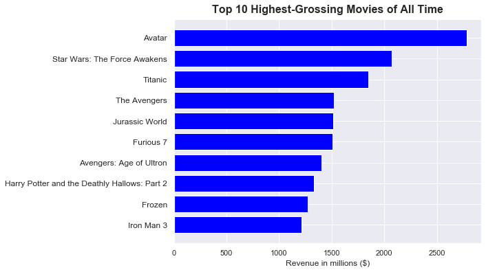

```python
# horizontal bar chart seems to be the most appropriate visualization to show monetary ranking
plt.figure(figsize=(8,6))
plt.barh(data=top10_revenue, width='revenue', y='original_title', color='blue')
plt.title('Top 10 Highest-Grossing Movies of All Time', size=16, weight='bold', position=(0.5,1.01))
plt.yticks(size=12)
plt.xlabel('Revenue in millions ($)')
plt.ylabel('')
plt.show()
```

All the top 10 high-grossing movies of all time were released in the 2000s except for Titanic which was released in 1997. Titanic was the highest-grossing film for 12 years and was surpassed by Avatar in 2010, both of which were directed by James Cameron.

#### Top 10 Most Expensive Movies of All Time

```python
# sort data by budget from highest to lowest and assign to a variable
top10_budget = movies.sort_values(by='budget',ascending=False).head(10)
top10_budget.sort_values(by='budget', inplace=True)
```

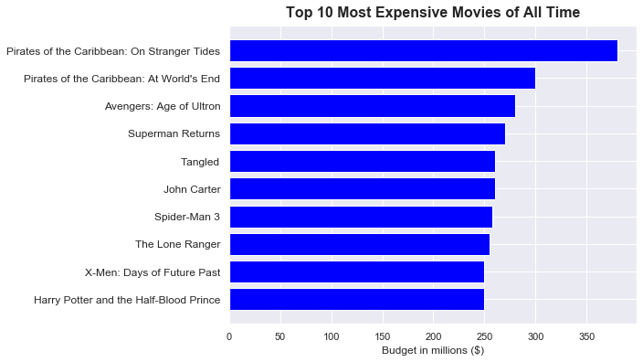

```python
plt.figure(figsize=(8,6))
plt.barh(data=top10_budget, width='budget', y='original_title', color='blue')
plt.title('Top 10 Most Expensive Movies of All Time', size=16, weight='bold', position=(0.5,1.01))
plt.yticks(size=12)
plt.xlabel('Budget in millions ($)')
plt.ylabel('')
plt.show()
```

Two movies from the Pirates of the Caribbean franchise came in as the top 2 most expensive movies of all time. Despite the list being the most expensive movies of all time, only two films reached the 1 billion dollar mark, namely *Pirates of the Caribbean: On Stranger Tides* and *Avengers: Age of Ultron*. The Lone Ranger's disappointing performance incurred a loss of an estimated 160 million dollars. A combination of Action, Adventure, Fantasy and Science Fiction were common genres in high-budget films.

#### Top 10 Highest-Rated Movies

For the rating (vote_average) to be reliable, it needs to be backed by a large number of user votes (vote_count). I used the top 50 highest vote_count then sorted the movies by rating to get the highest-rated movies based on TMDb's data.

```python
# sort data by vote_count from highest to lowest and assign to a variable
top50_votecount = movies.sort_values(by='vote_count', ascending=False).head(50)
```

```python
# select columns needed to present high movie ratings and assign to a variable
columns = ['original_title','release_year','vote_average','vote_count']
```

```python
# filter top50_votecount with the columns needed and sort by vote_average from highest to lowest
high_rating = top50_votecount[columns].sort_values('vote_average', ascending=False)
```

```python
# this code is for making the list a little more presentable
high_rating.set_index('original_title', inplace=True) # set index to movie title
high_rating.columns = ['Year Released','Rating', 'Vote Count'] # rename columns
high_rating.index.rename('Movie Title',inplace=True) # rename index name
```

```python
# filter top 10 vote_average
top10_rating = high_rating.head(10)
top10_rating
```

| Movie Title | Year Released | Rating | Vote Count |
| --- | --- | --- | --- |
| The Shawshank Redemption | 1994 | 8.4 | 5754 |
| The Godfather | 1972 | 8.3 | 3970 |
| Fight Club | 1999 | 8.1 | 5923 |
| The Dark Knight | 2008 | 8.1 | 8432 |
| Forrest Gump | 1994 | 8.1 | 4856 |
| Pulp Fiction | 1994 | 8.1 | 5343 |
| The Empire Strikes Back | 1980 | 8.0 | 3954 |
| Interstellar | 2014 | 8.0 | 6498 |
| The Wolf of Wall Street | 2013 | 7.9 | 4027 |
| Star Wars | 1977 | 7.9 | 4428 |

The Dark Knight, Interstellar, and The Wolf of Wall Street are the only movies released in the 2000's. Notably, two movies from Lucasfilm made it to the list, namely, Star Wars: New Hope and Star Wars: The Empire Strikes Back. Additionally, The Dark Knight and Interstellar, both of which were directed by Christopher Nolan, received an impressive viewer rating. The most popular genres in high-rated films are Drama, Action, and Adventure.

Interesting facts! Now that we've scratched the surface, it's time to dig deeper. Let's start analyzing!

### What are features associated with movies that have high revenues?

> For this question, we'll look into the qualities and characteristics associated in high-grossing movies. The independent variables we're analyzing are budget, genre, and timing of release, while the dependent variable is revenue. The adjusted dollar figures will be used in this analysis to account for inflation over time.

#### Budget

First, let's take a look at the distribution of budget and revenue data.

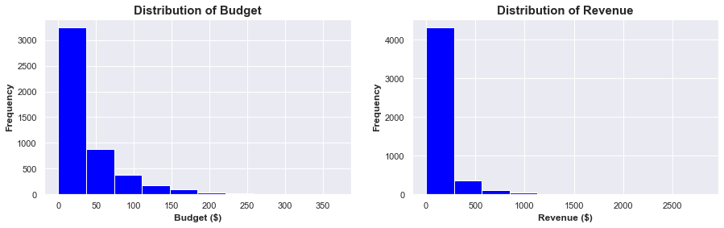

```python
fig, (ax1, ax2) = plt.subplots(1,2, figsize=(15,4))
ax1.hist(data=movies, x='budget_adj', color='blue')
ax1.set_title('Distribution of Budget', size=15, weight='bold')
ax1.set_xlabel('Budget ($)', weight='bold')
ax1.set_ylabel('Frequency', weight='bold')
ax2.hist(data=movies, x='revenue_adj', color='blue')
ax2.set_title('Distribution of Revenue', size=15, weight='bold')
ax2.set_xlabel('Revenue ($)', weight='bold')
ax2.set_ylabel('Frequency', weight='bold')
plt.show()
```

Both budget and revenue are skewed to the right which means the data are concentrated in the lower dollar figures. Now let's check if there's a relationship between budget and revenue.

```python
# create a copy of movies dataframe but only select budget and revenue columns and assign to a variable
budget_movies = movies[['budget_adj', 'revenue_adj']].copy()
```

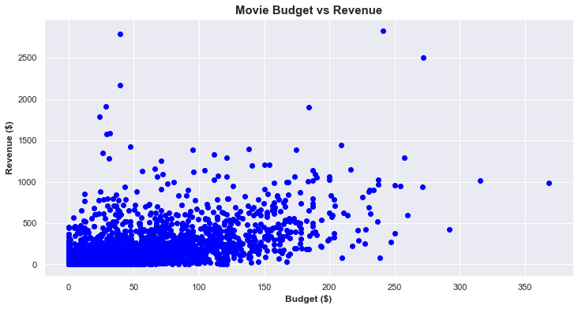

```python
plt.figure(figsize=(12,6))
plt.scatter(data=budget_movies, x='budget_adj', y='revenue_adj', color='blue')
plt.title('Movie Budget vs Revenue', size=15, weight='bold')
plt.xlabel('Budget ($)', weight='bold')
plt.ylabel('Revenue ($)', weight='bold')
plt.show();
```

We can see there's a very slight correlation between budget and revenue. There are low-budget movies that generated high-revenue and vice-versa. We'll also have to see the spread of data and the average revenue by budget. To understand better, let's categorize budget into three: High, Mid, and Low.

It will also be helpful to look at the volume of movies in each budget category.

```python
# by using .map() and lambda function, we can categorize the budget figures to High and Low
# assign the result to new column budget_level
movies['budget_level'] = movies.budget_adj.map(lambda x: "High" if x > 100 else "Low" if x < 10 else 'Mid')
```

```python
# group observation by budget_level by mean and filter out revenue
# assign the result to new column ave_rev
ave_rev = movies.groupby('budget_level').mean()['revenue_adj']
ave_rev
```

```
budget_level
High    430.288013
Low      30.297051
Mid     121.791318
Name: revenue_adj, dtype: float64
```

```python
# get the number of each budget category and normalize
budget_vol = movies.budget_level.value_counts(normalize=True)
budget_vol
```

```
Mid     0.557228
Low     0.358218
High    0.084554
Name: budget_level, dtype: float64
```

```python
# compute proportion of ave_rev and assign to prop_ave_rev variable
prop_ave_rev = ave_rev/ave_rev.sum()
prop_ave_rev
```

```
budget_level
High    0.738849
Low     0.052023
Mid     0.209128
Name: revenue_adj, dtype: float64
```

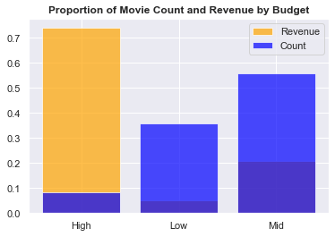

```python
# visualize comparison of the proportion between movie count and revenue by budget
plt.bar(x=prop_ave_rev.index, height=prop_ave_rev, alpha=0.7, color='orange', label='Revenue')
plt.bar(x=budget_vol.index, height=budget_vol, alpha=0.7, color='blue', label='Count')
plt.title('Proportion of Movie Count and Revenue by Budget', size=12, weight='bold')
plt.legend(bbox_to_anchor=(1,1))
plt.show()
```

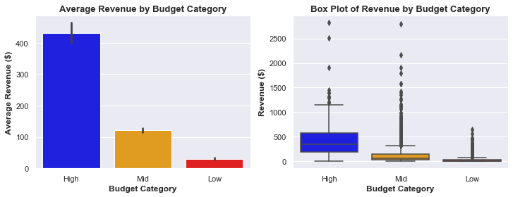

```python
# visualize the average reven
fig, (ax1, ax2) = plt.subplots(1,2, figsize=(12,4))
# bar chart: visualization for average revenue by budget category
sns.barplot(data=movies, x='budget_level', y='revenue_adj', ax=ax1, palette=['blue', 'orange', 'red'])
ax1.set_title('Average Revenue by Budget Category', size=13, weight='bold')
ax1.set_xlabel('Budget Category', weight='bold')
ax1.set_ylabel('Average Revenue ($)', weight='bold')
# boxplot: visualization for the spread of revenue by budget category
sns.boxplot(data=movies, x='budget_level', y='revenue_adj', ax=ax2, palette=['blue', 'orange','red'])
ax2.set_title('Box Plot of Revenue by Budget Category', size=13, weight='bold')
ax2.set_xlabel('Budget Category', weight='bold')
ax2.set_ylabel('Revenue ($)', weight='bold')
plt.show()
```

There are significantly more mid to low-budget films. Among the three budget categories, high-budget films have lower volume but higher revenue on average. In addition, If we look at the boxplot, we can see that high-budget films has higher and wider interquartile range (IQR) while mid and low-budget films have lower and narrower IQR. Revenue for high-budget films has more variability and tends to have higher revenue.

#### Timing of Release

We'll be looking into the time of movie release on the month level in relation to revenue. The new column release_month we created will be helpful in this analysis. In addition, we'll also discuss on which months have more movie releases and when are high-budget movies usually released.

First, let's see which month of release generates the most revenue.

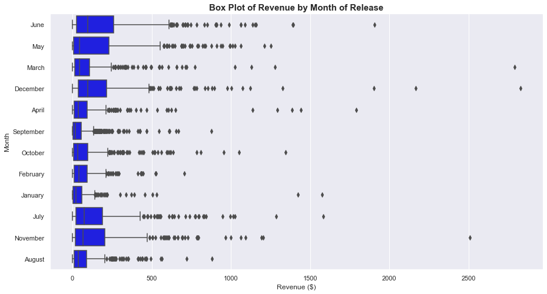

```python
plt.figure(figsize=(15,8))
#box plot: visualize the spread of revenue by month and identify IQR
sns.boxplot(data=movies, y='release_month', x='revenue_adj', color='blue')
plt.title('Box Plot of Revenue by Month of Release', size=15, weight='bold')
plt.xlabel('Revenue ($)')
plt.ylabel('Month');
```

The upper quartile of May, June, July, November and December are higher and have longer whiskers in the higher observations which means these months have higher revenues compared to the rest of the months. In addition, June and December has the highest median among all months. September and January revenues are more concentrated on lower observations.

Now let's look at the average revenue of movies released by month.

```python
# group observations by release_month using .groupby() and get the average of revenue
month_revenue = movies.groupby('release_month').revenue_adj.mean().sort_values(ascending=False)
```

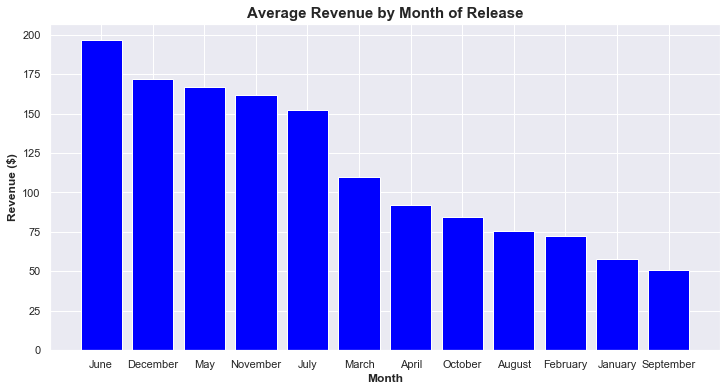

```python
fig, ax = plt.subplots(figsize=(12,6))
#bar chart: visualize average revenue by month of release
plt.bar(x=month_revenue.index, height=month_revenue, color='blue')
plt.title('Average Revenue by Month of Release', size=15, weight='bold')
plt.xlabel('Month', weight='bold')
plt.ylabel('Revenue ($)', weight='bold')
plt.show()
```

Same as our observation from the box plot, movies released in the months of May, June July, November and December have higher revenue on average while January, February, and September have lower revenues.

Both visualizations showed the same release months having high and low revenues. However, this may be affected by the volume of movies released by month. June may have more movies released than September thus having higher revenues. Could this be the case? Let's find out!

```python
# get the number of movies released by month by using .value_counts() and assign to variable month_count
month_count = movies.release_month.value_counts()
```

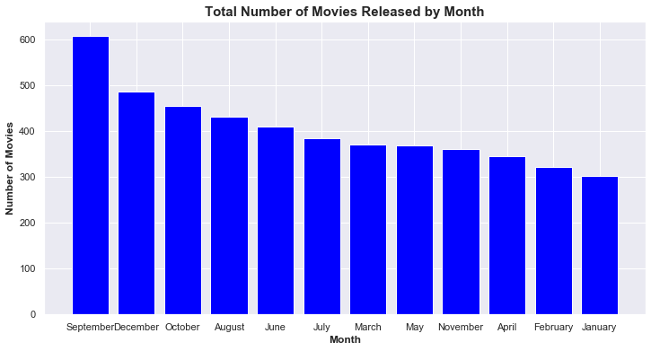

```python
fig, ax = plt.subplots(figsize=(12,6))
# bar chart: visualize number of movies released by month
plt.bar(x=month_count.index, height=month_count, color='blue')
plt.title('Total Number of Movies Released by Month', size=15, weight='bold')
plt.xlabel('Month', weight='bold')
plt.ylabel('Number of Movies', weight='bold')
plt.show()
```

Our assumption was the opposite. September, which has the lowest revenue output, has the highest volume of movie releases among all months. December also have high volumes while summer months, May, June, July are around the average number of releases in a month.

If September has high volume of movie releases then why does it have low revenue output? Let's have a look at the budget in relation to release months.

```python
# group observations by release_month using .groupby() and get the average of budget
month_budget = movies.groupby('release_month').budget_adj.mean().sort_values(ascending=False)
```

```python
# to compare the volume and average budget by month, compute for the proportion of each set
prop_month_budget = month_budget/month_budget.sum()
prop_month_count = month_count/month_count.sum()
```

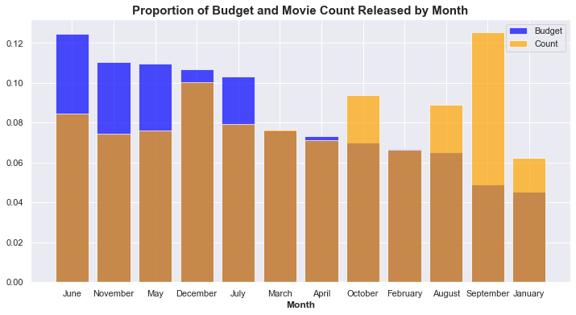

```python
fig, ax = plt.subplots(figsize=(12,6))
# bar chart: visualize the comparison of proportion of number of movies and budget by month of release
plt.bar(x=prop_month_budget.index, height=prop_month_budget, alpha=0.7, label='Budget',color='blue')
plt.bar(x=prop_month_count.index, height=prop_month_count, alpha=0.7, label='Count', color='orange')
plt.title('Proportion of Budget and Movie Count Released by Month', size=15, weight='bold')
plt.xlabel('Month', weight='bold')
plt.legend(bbox_to_anchor=(1,1));
```

Let's move on the last independent variable, genre, which, personally, is the most interesting among the three variables.

#### Genre

Because a movie may have multiple genres, we have to separate each genre and create a new DataFrame. After separating, we'll have multiple entries for one movie to reflect its different genres.

**IMPORTANT**: *Using the new DataFrame will cause double-counting and may result in incorrect information when using aggregates. For example, total revenue, total budget, total number of movies will be overstated.*

```python
# create a list of columns needed for this section
columns = ['budget_adj', 'revenue_adj', 'genres','release_year']
```

```python
# create a copy of movies DataFrame and assign to variable genres
genres = movies[columns].copy()
```

SPLITTING GENRES: The genres data is separated by '|' which will be used to separate multiple genres.

```python
# separate each genre by calling the separator using .str.split('|')
# calling 'expand=True' in .split() will separate each genre into columns instead of lists
# place each result in a new row using .stack()
# assign results in variable split
split = genres.genres.str.split('|', expand=True).stack()
```

The result will have two indexes, the original and inside the original index is a new index. To join the new result to the genres dataset, the indexes need to be similar.

```python
# drop the new index to reflect original index of the movie for each genre using .droplevel(1)
split = split.droplevel(1)
```

```python
# needs to have a name to join with genres dataset
split.name = 'genres'
```

```python
# drop the genres column in the genres dataset to be replaced by the separated genres
genres.drop('genres', axis=1, inplace=True)
```

```python
# join genres dataset to split
genres = genres.join(split)
```

```python
genres.head()
```

|  | budget_adj | revenue_adj | release_year | genres |
| --- | --- | --- | --- | --- |
| 0 | 137.999939 | 1392.445893 | 2015 | Action |
| 0 | 137.999939 | 1392.445893 | 2015 | Adventure |
| 0 | 137.999939 | 1392.445893 | 2015 | Science Fiction |
| 0 | 137.999939 | 1392.445893 | 2015 | Thriller |
| 1 | 137.999939 | 348.161293 | 2015 | Action |

We now have a new dataset where each genre of one movie is separated into rows. Let's look at the average budget and revenue for each genre.

```python
# group observations by genre and get the average assign to variable genre_grp
genre_grp = genres.groupby('genres').mean()
# assign revenue data from genres dataset to variable genre_revenue
genre_revenue = genre_grp.revenue_adj.sort_values()
# assign budget data from genres dataset to variable genre_budget
genre_budget = genre_grp.budget_adj.sort_values()
```

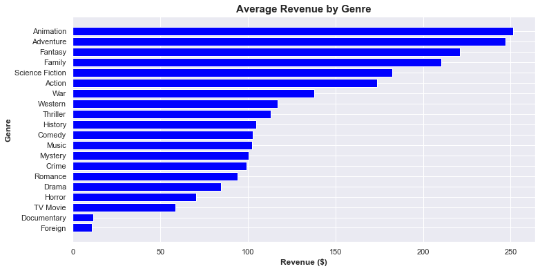

```python
fig, ax = plt.subplots(figsize=(12,6))
# horizontal bar chart: visualization for average revenue by genre
plt.barh(y=genre_revenue.index, width=genre_revenue, color='blue')
plt.title('Average Revenue by Genre', size=15, weight='bold')
plt.ylabel('Genre', weight='bold')
plt.xlabel('Revenue ($)', weight='bold')
plt.show()
```

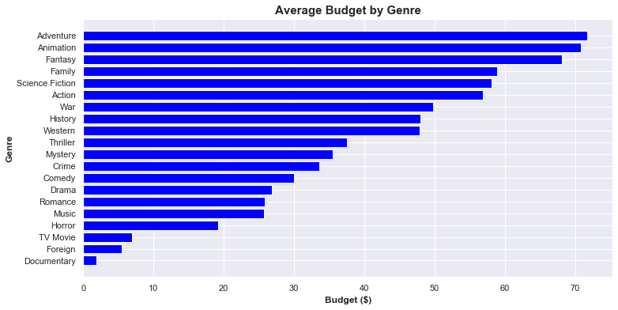

```python
fig, ax = plt.subplots(figsize=(12,6))
# horizontal bar chart: visualization for average budget by genre
plt.barh(width=genre_budget, y=genre_budget.index, color='blue')
plt.title('Average Budget by Genre', size=15, weight='bold')
plt.ylabel('Genre', weight='bold')
plt.xlabel('Budget ($)', weight='bold')
plt.show()
```

The average budget and revenue by genre are virtually identical. On average, Adventure, Animation, Fantasy, Family, Science Fiction, and Action are the most expensive movie genres to produce but also generates the most revenue. Does this mean more or less movies with these genres? Let's look at the volume of movies for each genre to answer the question.

```python
# get the number of movies by genre by using .value_counts() and assign to variable genre_count
genre_count = genres.genres.value_counts()
genre_count.sort_values(inplace=True)
```

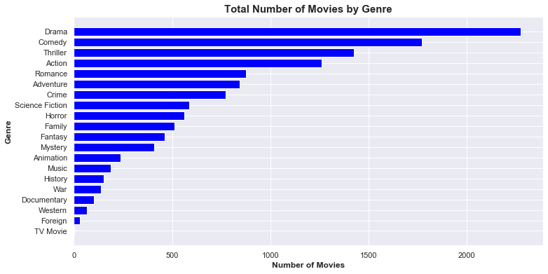

```python
fig, ax = plt.subplots(figsize=(12,6))
# horizontal bar chart: visualization for total number of movies by genre
plt.barh(data=genre_count, y=genre_count.index, width=genre_count, color='blue')
plt.title('Total Number of Movies by Genre', size=15, weight='bold')
plt.ylabel('Genre', weight='bold')
plt.xlabel('Number of Movies', weight='bold')
plt.show()
```

Drama is the most popular in genre movies followed by Comedy and Thriller. The three genres are in the middle to lower end in terms of budget and revenue. The most expensive genres are somewhere in the middle with Animation having least number of movies. To understand better, let's compare volume and budget.

```python
# to compare the volume and average budget, compute for the proportion of each set
prop_genre_budget = genre_budget/genre_budget.sum()
prop_genre_count = genre_count/genre_count.sum()
```

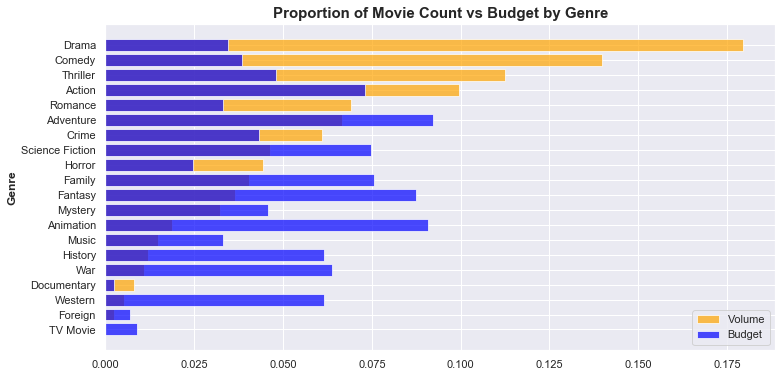

```python
fig, ax = plt.subplots(figsize=(12,6))
# horizontal bar chart: visualization for comparison of proportion of volume, budget, revenue by genre
plt.barh(width=prop_genre_count, y=prop_genre_count.index, alpha=0.7, label='Volume', color='orange')
plt.barh(width=prop_genre_budget, y=prop_genre_budget.index, alpha=0.7, label='Budget', color='blue')
plt.title('Proportion of Movie Count vs Budget by Genre', size=15, weight='bold')
plt.ylabel('Genre', weight='bold')
plt.legend()
plt.show()
```

On average, among the most expensive movie genres, Animation, has the least volume of movie genre produced while the most popular genres, Drama, Comedy, and Thriller are not expensive nor cheap to make.

### Does high-budget movies mean higher viewer ratings?

```python
low = movies.budget_level== "Low"
mid = movies.budget_level== "Mid"
high = movies.budget_level== "High"
```

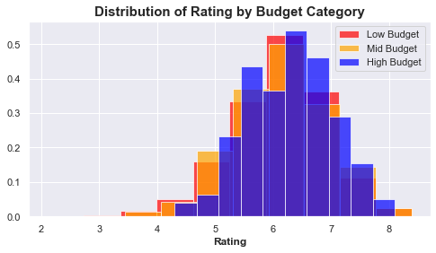

```python
plt.figure(figsize=(8,4))
#histogram for vote_average by budget category
plt.hist(x=movies.vote_average[low], alpha=0.7, density=True, color='red', label = 'Low Budget')
plt.hist(x=movies.vote_average[mid], alpha=0.7, density=True, color='orange', label = 'Mid Budget')
plt.hist(x=movies.vote_average[high], alpha=0.7, density=True, color='blue', label = 'High Budget')
plt.legend()
plt.xlabel('Rating', weight='bold')
plt.title('Distribution of Rating by Budget Category', size=15, weight='bold')
plt.show()
```

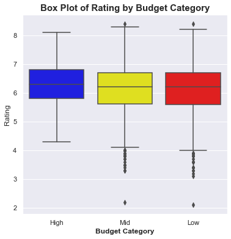

```python
fig, ax = plt.subplots(figsize=(6,6))
# box plot: visualize the spread of viewer ratings by budget category
sns.boxplot(data=movies, x='budget_level', y='vote_average', palette=['blue','yellow','red'])
plt.title('Box Plot of Rating by Budget Category', size=15, weight='bold')
plt.xlabel('Budget Category', weight='bold')
plt.ylabel('Rating')
plt.show()
```

### Are there changes in most popular genres in the past years?

We are going to look at the volume of movies by genre from 1970-2015 and find out if there are significant changes in the kind of movies released between those years. We need to get the the number of each genre released per year.

```python
# make a list of columns needed for this analysis
columns = ['genres','release_year']
```

```python
# group data by the columns selected and assign to genres_by_year
# get the number of moviesj by genre each year by using .size()
genres_by_year = genres.groupby(columns).size()
```

```python
# use the index as columns using .unstack()
# fill null values with zero by calling fill_value=0
genres_by_year = genres_by_year.unstack(level=0, fill_value=0)
```

```python
# use 10 year moving average to smooth out the data by using .rolling()
genres_by_year = genres_by_year.rolling(10).mean()
```

```python
# drop null values
genres_by_year.dropna(inplace=True)
```

```python
# create a list of unique genres
genre_list = genres_by_year.columns
```

```python
def year_genre(x=genre_list):
    plt.figure(figsize=(15,8))

    for i in x:
        plt.plot(genres_by_year[i], label=i)
    plt.title('Number of Movies by Genre', size=15, weight='bold')
    plt.xlabel('Years', weight='bold')
    plt.ylabel('Number of Movies', weight='bold')
    plt.xticks()
    plt.legend(loc='upper left',bbox_to_anchor=(1,1))
    plt.show()
```

```python
genres.genres.value_counts().head(10).index
```

```
Index(['Drama', 'Comedy', 'Thriller', 'Action', 'Romance', 'Adventure',
       'Crime', 'Science Fiction', 'Horror', 'Family'],
      dtype='object')
```

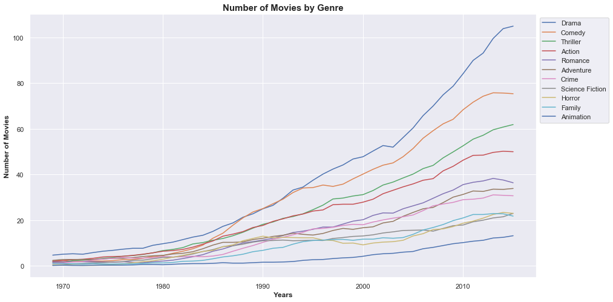

```python
year_genre(['Drama', 'Comedy', 'Thriller', 'Action', 'Romance', 'Adventure',
       'Crime', 'Science Fiction', 'Horror', 'Family', 'Animation'])
```

## Conclusions

> We looked at three independent variables, amount of budget, timing of release, and genre, to determine the characteristics of movies that have high-revenue. On average, high-revenue movies have high budgets, released on the months of May, June, July, December, and November, and have a combination of Animation, Adventure, Action, Family, Fantasy, and Science Fiction.

> The average viewer rating for all budget categories doesn't have a significant difference, which means higher budget doesn't entirely correspond to higher ratings. However, movies having more than 100 million dollars has lesser variation in ratings because data is more concentrated in the higher end of the observation. High-budget movies have the highest among the lowest ratings in each category.

> Lastly, drama movies has been the most popular genre over the years. Action and thriller movies are identical in numbers until the mid-90's where action movies seemed to slow down. Animation has the steadiest growth among all genres.

### Limitations

> The conclusions stated above refers to a sample of the entire population which are movies with reported revenues. To remain consistent on across the board, there are features needed to be omitted for the analysis to be intact. The limitations and assumptions are:

> **Revenue**: The main dependent variable in this analysis is revenue, therefore, we need data on movies with revenue figures. There are movies in the dataset with zero reported values which can mean two things: the movie did not make any revenue, or no revenue is null. Including these figures would affect the overall analysis and result. These instances will be treated as null values for revenue, hence, will be dropped.

> **Budget**: Similar instance with revenue, budget figures also have zero-reported figures. Because we dropped the rows having zero revenue, we also eliminated some rows with zero budgets but not everything. The assumption, therefore, will be treated as no budget movies.

### References

https://stackoverflow.com/

https://developers.themoviedb.org/3/getting-started/popularity

https://www.kaggle.com/tmdb/tmdb-movie-metadata